# A Modern Approach to Regression with R Exercises

Rachel Greenlee

9/3/2021

### Datasets at this link:

https://gattonweb.uky.edu/sheather/book/data_sets.php

## Chapter 2 Exercises

1. The web site www.playbill.com provides weekly reports on the box office ticket sales for plays on Broadway in New York. We shall consider the data for the week October 11–17, 2004 (referred to below as the current week). The data are in the form of the gross box office results for the current week and the gross box office results for the previous week (i.e., October 3–10, 2004). The data, plotted in Figure 2.6 , are available on the book web site in the file playbill.csv.

Fit the following model to the data: Y = b0 + b1x + e where Y is the gross box office results for the current week (in $) and x is the gross box office results for the previous week (in $). Complete the following tasks:

```r
box_tx <- fread("https://gattonweb.uky.edu/sheather/book/docs/datasets/playbill.csv")
```

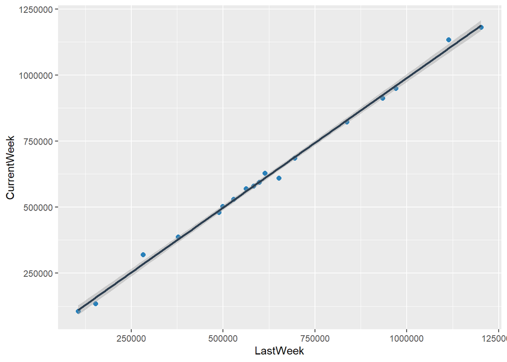

```r
# graph the variables with a linear regression line through the points
ggplot(box_tx, aes(x=LastWeek, y=CurrentWeek)) +
  geom_point(color='#2980B9', size = 2) +
  geom_smooth(method=lm, color='#2C3E50')
```

```r
# make the model and check summar
tx_lm1 <- lm(CurrentWeek ~ LastWeek, data = box_tx)
summary(tx_lm1)
```

```
##
## Call:
## lm(formula = CurrentWeek ~ LastWeek, data = box_tx)
##
## Residuals:
##    Min     1Q Median     3Q    Max
## -36926  -7525  -2581   7782  35443
##
## Coefficients:
##              Estimate Std. Error t value Pr(>|t|)
## (Intercept) 6.805e+03  9.929e+03   0.685    0.503
## LastWeek    9.821e-01  1.443e-02  68.071   <2e-16 ***
## ---
## Signif. codes:  0 '***' 0.001 '**' 0.01 '*' 0.05 '.' 0.1 ' ' 1
##
## Residual standard error: 18010 on 16 degrees of freedom
## Multiple R-squared:  0.9966, Adjusted R-squared:  0.9963
## F-statistic:  4634 on 1 and 16 DF,  p-value: < 2.2e-16
```

1. Find a 95% confidence interval for the slope of the regression model, b1 . Is 1 a plausible value for b1 ? Give a reason to support your answer.

The confidence interval for the slope is 0.9515 to 1.0127. A slope of 1 means that the response variable increases just as fast as the explanatory variable increases. The scatterplot above shows a slope of nearly 1 that appears perfectly diagnol when on equal axes.

```r
# find conf intervals at 95% level
confint(tx_lm1, level = 0.95)
```

```
##                     2.5 %       97.5 %
## (Intercept) -1.424433e+04 27854.099443
## LastWeek     9.514971e-01     1.012666
```

2. Test the null hypothesis 0 0 H : b = 10000 against a two-sided alternative. Interpret your result.

H_0:$\beta_0$ = 10000 H_1:$\beta_0 \neq$ 10000

Since the two-tailed confidence interval below includes 10,000 in the slope range we cannot reject the null hypothesis.

```r
# find the confidence interval for the intercept at 95%
confint(tx_lm1, '(Intercept)', level=0.95)
```

```
##                 2.5 %  97.5 %
## (Intercept) -14244.33 27854.1
```

3. Use the fitted regression model to estimate the gross box office results for the current week (in $) for a production with $400,000 in gross box office for the previous week. Find a 95% prediction interval for the gross box office results for the current week (in $) for a production with $400,000 in gross box office the previous week. Is $450,000 a feasible value for the gross box office results in the current week, for a production with $400,000 in gross box office the previous week? Give a reason to support your answer.

Using the predict function I see that the exact prediction is just under $400,000. This makes sense with the slope so close to 1 we found earlier, as that’s esentially the multiplyer for the last week value X ~1 to get the current week value.

```r
predict(tx_lm1, data.frame(LastWeek = 400000), interval = "predict", level = 0.95)
```

```
##        fit      lwr      upr
## 1 399637.5 359832.8 439442.2
```

2. A story by James R. Hagerty entitled With Buyers Sidelined, Home Prices Slide published in the Thursday October 25, 2007 edition of the Wall Street Journal contained data on so-called fundamental housing indicators in major real estate markets across the US. The author argues that… prices are generally falling and overdue loan payments are piling up . Thus, we shall consider data presented in the article on

Y = Percentage change in average price from July 2006 to July 2007 (based on the S&P/Case-Shiller national housing index); and

x = Percentage of mortgage loans 30 days or more overdue in latest quarter (based on data from Equifax and Moody’s).

The data are available on the book web site in the file indicators.txt. Fit the following model to the data: Y = b0 + b1x + e . Complete the following tasks:

```r
housing_df <- read.table('https://gattonweb.uky.edu/sheather/book/docs/datasets/indicators.txt', header=TRUE)

head(housing_df)
```

```
##   MetroArea PriceChange LoanPaymentsOverdue
## 1   Atlanta         1.2                4.55
## 2    Boston        -3.4                3.31
## 3   Chicago        -0.9                2.99
## 4    Dallas         0.8                4.26
## 5    Denver        -0.7                3.56
## 6   Detroit        -9.7                4.71
```

1. Find a 95% confidence interval for the slope of the regression model, b1 . On the basis of this confidence interval decide whether there is evidence of a significant negative linear association.

The 95% confidence interval only contains negative numbers for the slope (second line below) so we can say there is evidence for a negative linear association (slope).

```r
# create the model
housing_lm1 <- lm(PriceChange ~ LoanPaymentsOverdue, data = housing_df)

# find conf intervals at 95% level
confint(housing_lm1, level = 0.95)
```

```
##                         2.5 %     97.5 %
## (Intercept)         -2.532112 11.5611000
## LoanPaymentsOverdue -4.163454 -0.3335853
```

2. Use the fitted regression model to estimate E ( Y | X =4). Find a 95% confidence interval for E ( Y | X =4). Is 0% a feasible value for E ( Y | X =4)? Give a reason to support your answer.

The lower and upper limits shown below all remain less than 0%, so this would not be a feasible value.

```r
predict(housing_lm1, data.frame(LoanPaymentsOverdue = 4), interval = "confidence", level = 0.95)
```

```
##         fit       lwr       upr
## 1 -4.479585 -6.648849 -2.310322
```

3. The manager of the purchasing department of a large company would like to develop a regression model to predict the average amount of time it takes to process a given number of invoices. Over a 30-day period, data are collected on the number of invoices processed and the total time taken (in hours). The data are available on the book web site in the file invoices.txt. The following model was fit to the data: 0 1 Y = b + b x + e where Y is the processing time and x is the number of invoices. A plot of the data and the fitted model can be found in Figure 2.7 . Utilizing the output from the fit of this model provided below, complete the following tasks.

```r
inv_df <- read.table('https://gattonweb.uky.edu/sheather/book/docs/datasets/invoices.txt', header=TRUE)

head(inv_df)
```

```
##   Day Invoices Time
## 1   1      149  2.1
## 2   2       60  1.8
## 3   3      188  2.3
## 4   4       23  0.8
## 5   5      201  2.7
## 6   6       58  1.0
```

```r
inv_lm1 <- lm(Time ~ Invoices,
              data = inv_df)
summary(inv_lm1)
```

```
##
## Call:
## lm(formula = Time ~ Invoices, data = inv_df)
##
## Residuals:
##      Min       1Q   Median       3Q      Max
## -0.59516 -0.27851  0.03485  0.19346  0.53083
##
## Coefficients:
##              Estimate Std. Error t value Pr(>|t|)
## (Intercept) 0.6417099  0.1222707   5.248 1.41e-05 ***
## Invoices    0.0112916  0.0008184  13.797 5.17e-14 ***
## ---
## Signif. codes:  0 '***' 0.001 '**' 0.01 '*' 0.05 '.' 0.1 ' ' 1
##
## Residual standard error: 0.3298 on 28 degrees of freedom
## Multiple R-squared:  0.8718, Adjusted R-squared:  0.8672
## F-statistic: 190.4 on 1 and 28 DF,  p-value: 5.175e-14
```

```r
# to get 95% confidence interval for y-intercept
confint(inv_lm1, '(Intercept)', level = 0.95)
```

```
##                 2.5 %    97.5 %
## (Intercept) 0.3912496 0.8921701
```

2. Suppose that a best practice benchmark for the average processing time for an additional invoice is 0.01 hours (or 0.6 minutes). Test the null hypothesis 0 1 H : b = 0.01 against a two-sided alternative. Interpret your result. **Yes the range of the slope in this confidence interval contains 0.01, as the range is 0.0096 to 0.0130.**

```r
# check confidence interval range for the given null hypothesis
confint(inv_lm1, 'Invoices', level = 0.95)
```

```
##                2.5 %     97.5 %
## Invoices 0.009615224 0.01296806
```

3. Find a point estimate and a 95% prediction interval for the time taken to process 130 invoices. **The exact prediction is 2.1096, with a confidence interval spanning 1.4229 to 2.7963.**

```r
predict(inv_lm1, data.frame(Invoices = 130), interval = "predict", level = 0.95)
```

```
##        fit      lwr    upr
## 1 2.109624 1.422947 2.7963
```